# U.S. Job Market Analysis

ESSHA KHAN

Open to opportunities

← All projects

View the full project repository  
[GitHub →](https://github.com/esshak-bu/job-market-analysis-project-2024)

01 CLOUD ANALYTICS PROJECT

# What can 1M+ job postings tell us about the future of data work?

I analyzed real-world Lightcast job-market data to understand how data roles are evolving in the age of AI. From in-demand skills and salary differences to industry demand, experience requirements, and career pathways.

Python PySpark AWS SQL Machine Learning Plotly

[figure not shown]

RESEARCH QUESTIONS

## What did I want to understand?

01 — SKILLS

### Which skills are most in demand?

What are the most in-demand skills for data science, business analytics, and machine learning roles?

02 — AI SHIFT

### Are job descriptions changing?

Have job descriptions evolved in 2024 to require more AI and machine-learning expertise?

03 — INDUSTRIES

### Where is hiring strongest?

What industries are hiring the most data professionals, and where is demand concentrated?

04 — CAREER

### What is the outlook for analytics?

What do these market patterns suggest about the career outlook for business analytics professionals?

02 RESEARCH RATIONALE

## Why study the changing boundaries between data roles?

Data analyst work is increasingly moving beyond dashboards and traditional reporting toward deeper business context, automation, and responsibilities that overlap with data science, data engineering, and machine learning. At the same time, AI can automate many routine technical tasks, making the skill of being able to interpret data within a meaningful business context and translate analysis into decisions even more important.

Three trends made this especially relevant in 2024: growing demand for AI and advanced analytics, increased emphasis on hybrid skill sets that combine tools such as Python and SQL with business communication, and clearer separation between traditional analytics positions and more specialized AI-focused roles. Remote and hybrid work have also expanded access to opportunities while increasing competition.

I expected the market to reward both technical depth and business understanding, with noticeable differences in skills, experience, and compensation between traditional analytics and AI-oriented roles.

03 SKILLS BY ROLE

## Which skills are employers looking for?

Skill variables were processed independently to preserve the differences between software, specialized, common, and certification skill requirements. I cleaned the raw list fields, exploded them into individual observations, and ranked the most frequently occurring skills within each role category.

## Cleaning and extracting skills

The code below is copied directly from my project notebook.

PySpark

```python
# clean and extract skills
from pyspark.sql.functions import regexp_replace, split, explode, trim, lower, col, lit

# clean the string and remove unwanted characters such as list brackets, quotes, and new lines
def extract_skills(dataframe, skill_col, skill_type):
    cleaned = dataframe.withColumn(
        "SKILL_CLEAN",
        regexp_replace(col(skill_col), r'[\[\]\n"]', "")
    )

# explode so its one row per skill and rename column
    exploded = cleaned.select(
        "ROLE_CATEGORY",
        explode(split(col("SKILL_CLEAN"), ",")).alias("SKILL")
    )

# clean formatting so everything is lower, trim any spaces, and remove empty values
    return exploded.withColumn(
        "SKILL",
        trim(lower(col("SKILL")))
    ).filter(
        (col("SKILL").isNotNull()) & (col("SKILL") != "")
    ).withColumn(
        "SKILL_TYPE",
        lit(skill_type)
    )
```

## Ranking the top skills by role

I used a PySpark window function to identify the top 15 skills inside each role category.

PySpark

```python
# window function to extract and aggregate skill datasets to identify the top 15 most frequently occurring skills within each role category
from pyspark.sql.window import Window
from pyspark.sql.functions import col, row_number

def get_top_skills_by_role(df):
    counts = df.groupBy("ROLE_CATEGORY", "SKILL").count()

    window = Window.partitionBy("ROLE_CATEGORY").orderBy(col("count").desc())

    ranked = counts.withColumn(
        "rank",
        row_number().over(window)
    ).filter(col("rank") <= 15)

    return ranked
```

Software skills

[interactive chart not shown]

**✧ Key insight**

SQL, Python, and dashboarding tools appear consistently across all role categories, reinforcing them as foundational skills. Data Analyst postings lean more heavily on BI and reporting tools, while Data Scientist and AI-focused roles introduce a wider mix of programming, cloud, and machine-learning technologies.

### Additional skill analyses

The same pipeline was applied to specialized skills, common soft skills, and certifications.

**Explore specialized skills**

Role-specific technical and domain skills.

[interactive chart not shown]

**Explore common soft skills**

Cross-functional and business skills found in job postings.

Common Soft skills

[interactive chart not shown]

**Explore certifications**

Credential requirements varied substantially by role.

Certifications

[interactive chart not shown]

04 MARKET INSIGHTS

## Salaries, industries, experience & work arrangements

Skills are only one part of the market. I also compared compensation, industries, experience requirements, and work setup to understand how opportunities differ across data roles.

AI ENGINEER

### $180K

Median salary for AI Engineer/Analyst roles.

DATA SCIENTIST

### $127.6K

Median salary for Data Scientist roles.

DATA ANALYST

### $97K

Median salary for Data Analyst roles.

EXPERIENCE

### 39.6%

of postings fell into the 3–5 year mid-level group.

Salary comparison

[interactive chart not shown]

Top industries hiring

[interactive chart not shown]

Experience level distribution

[interactive chart not shown]

Experience × work setup

[interactive chart not shown]

**✧ Market insight**

Compensation rises with specialization: AI Engineer/Analyst roles had the highest median salary, followed by Data Scientists and Data Analysts. Hiring was concentrated in Finance & Insurance and Professional & Technical Services, while mid-level roles represented the largest experience group. Hybrid work dominated every experience level, with remote work consistently more common than onsite-only arrangements.

05 UNSUPERVISED LEARNING

## Can job postings reveal natural career groupings without relying on job titles?

Job titles are not always consistent across employers. I used K-Means clustering to explore whether data-related job postings would naturally form groups based on their underlying characteristics rather than their predefined role labels.

K-Means is an unsupervised learning algorithm, so the model was not given a target variable to predict. Instead, it searched for similarity across salary, minimum experience, education, and feature engineered technical-skill indicators.

MODEL **K-Means**

Unsupervised clustering

PySpark ML k = 4 PCA

MODEL PIPELINE

### From job postings to interpretable clusters

01 **Filter**

Focus on relevant data roles

→

02 **Engineer**

Create binary skill indicators

→

03 **Scale**

Standardize model features

→

04 **Select k**

Compare WSSSE solutions

→

05 **Cluster**

Fit the K-Means model

→

06 **Interpret**

PCA + cluster profiles

01 — FEATURE ENGINEERING

### How can job postings be represented by their technical skills?

I first combined the available skill fields into a single text representation. I then converted the presence of selected technical skills into binary features (1 = present, 0 = absent), allowing each job posting’s skill profile to be represented numerically for clustering.

Salary Experience Education Technical Skills

PySpark

```python
# combine all skill text
from pyspark.sql.functions import concat_ws, coalesce, lit

skill_cols = [
    "SKILLS_NAME",
    "SPECIALIZED_SKILLS_NAME",
    "SOFTWARE_SKILLS_NAME",
    "COMMON_SKILLS_NAME"
]

df_roles = df_roles.withColumn(
    "ALL_SKILLS_TEXT",
    lower(
        concat_ws(
            " ",
            *[coalesce(col(c), lit("")) for c in skill_cols]
        )
    )
)
```

PySpark

```python
# create binary skill features
from pyspark.sql.functions import regexp_extract

technical_skills = [
    "python","sql","excel","tableau","power bi",
    "machine learning","artificial intelligence",
    "data analysis","statistics","math",
    "linear algebra","probability","data visualization",
    "spark","aws","computer science"
]

df_skill_features = df_roles

for skill in technical_skills:
    clean_name = skill.replace(" ", "_").replace("-", "_").replace("/", "_")
    pattern = rf"\\b{skill.lower()}\\b"

    df_skill_features = df_skill_features.withColumn(
        f"skill_{clean_name}",
        (regexp_extract(col("ALL_SKILLS_TEXT"), pattern, 0) != "").cast("int")
    )
```

02 — PREPARING FEATURES FOR CLUSTERING

### Preparing the skill profiles for K-Means

After creating the binary skill indicators, I combined salary, minimum experience, education level, and the engineered skill variables into a single feature vector. PySpark's K-Means implementation expects the model inputs in this vector format. I then standardized the vector before applying the distance-based clustering model.

**Why standardize?**

K-Means groups observations using distance. Salary, experience, education, and binary skill indicators are measured on different numerical scales, so standardization keeps a high-magnitude variable such as salary from dominating the distance calculation simply because of its units.

03 — CHOOSING THE NUMBER OF CLUSTERS

### How many groups best represent the job market?

I trained candidate K-Means models for k = 2, 3, and 4 and compared their within-cluster sum of squared errors (WSSSE). Lower WSSSE means observations sit closer to their assigned cluster centers. The error continued to decline across the tested values, but the curve did not show a sharp elbow.

PySpark ML

```python
# compare candidate values of k
cost = []
k_values = range(2, 5)

for k in k_values:
    kmeans = KMeans(
        k=k,
        featuresCol="scaled_features",
        seed=42
    )
    model = kmeans.fit(df_model)
    cost.append(model.summary.trainingCost)
```

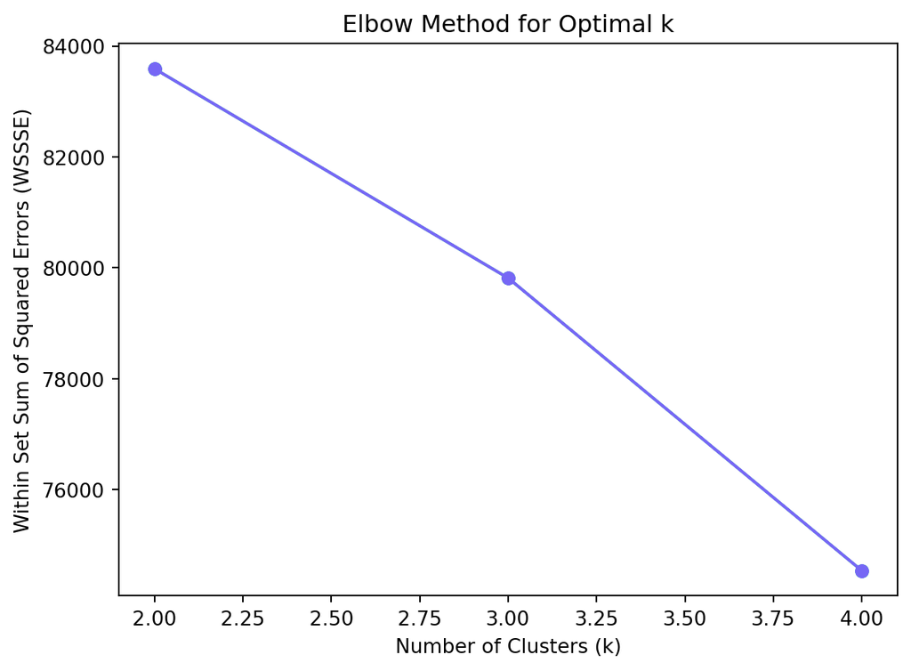

**Elbow-method comparison.** WSSSE falls from k = 2 through k = 4 without a dramatic bend, so the plot does not identify one unambiguous cluster count.

4

SELECTED CLUSTER COUNT

### Why k = 4?

I selected four clusters as an exploratory balance between additional segmentation and interpretability. Because the tested WSSSE curve does not contain a dramatic elbow, I do not treat four as the single “true” number of occupational groups; instead, I use it as a useful structure for examining different skill and job profiles.

04 — K-MEANS CLUSTERING

### Grouping postings by technical skill profile

Using the selected k = 4, I fit the final model on the standardized feature vectors and assigned each posting to its nearest cluster centroid.

PySpark ML

```python
# fit the selected four-cluster solution
kmeans = KMeans(k=4, featuresCol="scaled_features", seed=42)
model = kmeans.fit(df_model)
df_clustered = model.transform(df_model)
```

05 — INTERPRETING THE CLUSTERS

### What makes each cluster different?

I profiled each cluster by examining its dominant skills and broader job characteristics. The resulting groups were interpretable, but they represented different levels and types of specialization rather than four perfectly isolated occupations.

C0

PROFILE

### Traditional Analytics

C1

PROFILE

### Data Science

C2

PROFILE

### Generalist / Mixed

A more heterogeneous group with weaker concentration around one technical specialty.

C3

PROFILE

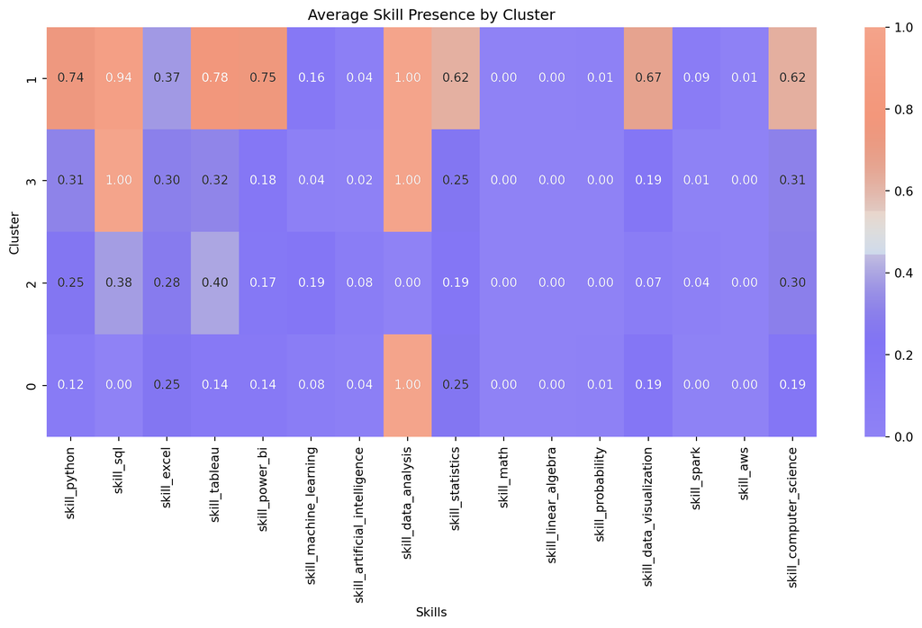

**Cluster 1**

Shows the broadest technical profile, with strong SQL, data analysis, Tableau, Power BI, Python, visualization, and statistics presence.

**Cluster 3**

Is strongly anchored by SQL and data analysis, but has much lower presence of the broader BI and advanced technical skills.

**Across clusters**

The groups differ mainly in skill combinations and intensity rather than completely exclusive skill sets.

06 — PCA VISUALIZATION

### How distinct are the clusters in a lower-dimensional view?

I used Principal Component Analysis (PCA) to project the high-dimensional model features into two dimensions. This makes the cluster structure easier to inspect visually, although PCA necessarily compresses information from the original feature space.

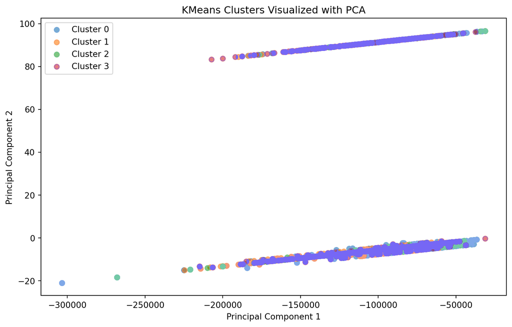

**PCA view of the four-cluster solution.** The colors overlap substantially rather than forming four isolated clouds, reinforcing that the underlying job profiles share many characteristics.

KEY MODEL FINDING **Data careers appear to exist on a spectrum.**

The elbow curve, cluster skill profiles, and PCA view tell a consistent story: meaningful differences in skill composition exist, but the boundaries are not rigid. Traditional analytics, BI, data science, and AI-oriented postings share many underlying capabilities and differ more by combinations and depth of skills than by completely separate occupational categories.

06 — CONCLUSION

### MODEL LIMITATIONS & NEXT TESTS

### Clustering is exploratory, not ground truth.

K-Means assumes distance-based, relatively compact clusters. The gradual WSSSE curve and PCA overlap indicate that this labor-market data does not naturally divide into sharply separated groups. PCA also compresses the full feature space into two dimensions, so some structure can be lost in visualization.

If I extended the model, I would test a wider range of k values using silhouette scores, compare cluster membership against the original role categories, and evaluate cluster stability across several random seeds. Those checks would help determine whether the observed groupings are consistently reproducible or primarily exploratory.

06 LITERATURE REVIEW

## Do the findings align with other labor-market research?

### Skills-based hiring & hybrid skill sets

Kobets et al. (2024) analyzed 3,744 job postings and used K-means clustering to identify four data-role groupings: Data Analyst & Engineer, Data Platform Engineer, Data Science & Engineering Specialist, and Cloud Data Engineer. Their results similarly suggest that modern data roles are increasingly defined by combinations of competencies rather than job titles alone.

The study highlights Python, SQL, cloud platforms such as AWS and Azure, data engineering, analytics, and machine learning as recurring requirements. It also identifies a gap between academic training and industry needs, reinforcing the importance of continuous upskilling and hybrid technical/business skill sets.

This provides useful external support for the patterns in my own analysis: SQL and Python function as core skills, specialized tools distinguish different career paths, and skill composition often provides a clearer picture of role structure than title alone.

Reference: [Kobets, Gulin, and Nosov (2024)](https://aait.od.ua/index.php/journal/article/view/154/154)